# Actividad 1.7 Componentes principales

Rey Iván De La Fuente Chávez

2026-08-25

Se realizará un Análisis de Componentes Principales (ACP) sobre 11 indicadores económicos y sociales de 96 países.

Se compararán dos procedimientos:

- ACP con la matriz de varianzas-covarianzas.
- ACP con la matriz de correlaciones.

El objetivo es determinar cuál representa mejor la estructura de los datos e interpretar las principales componentes obtenidas.

```r
# Librerías
suppressPackageStartupMessages({
  library(FactoMineR)
  library(factoextra)
})

# Cargar datos
datos <- read.csv("C:\\Users\\reyiv\\Downloads\\paises_mundo.csv")

# Variables utilizadas
X <- datos[, c("CrecPobl", "MortInf", "PorcMujeres", "PNB95",
               "ProdElec", "LinTelf", "ConsAgua", "PropBosq",
               "PropDefor", "ConsEner", "EmisCO2")]
```

# PARTE I - Valores y vectores propios

## 1. ACP con la matriz de varianzas-covarianzas

La matriz de covarianzas conserva las unidades y escalas originales de las variables.

```r
S <- cov(X)
round(S, 2)
```

```
##              CrecPobl     MortInf PorcMujeres         PNB95      ProdElec
## CrecPobl         1.54       21.95       -6.08 -8.933379e+04 -4.973964e+04
## MortInf         21.95     1032.86       -9.25 -2.269332e+06 -1.043435e+06
## PorcMujeres     -6.08       -9.25       76.98  2.813114e+05  2.260248e+05
## PNB95       -89333.79 -2269332.29   281311.42  4.999786e+10  2.247791e+10
## ProdElec    -49739.64 -1043435.44   226024.81  2.247791e+10  1.821909e+10
## LinTelf       -136.91    -4381.37      449.98  2.039550e+07  7.583050e+06
## ConsAgua       -48.27    -1288.21    -1568.31  1.097481e+07  1.399817e+07
## PropBosq        -3.89      -14.66       65.18  2.474311e+05  7.035979e+04
## PropDefor        0.34       12.76        0.27 -5.806203e+04 -3.180340e+04
## ConsEner      -838.42   -44425.68      285.52  1.415628e+08  6.801296e+07
## EmisCO2         -1.14      -94.86       -2.15  2.501673e+05  1.392779e+05
##                 LinTelf    ConsAgua  PropBosq PropDefor     ConsEner   EmisCO2
## CrecPobl        -136.91      -48.27     -3.89      0.34      -838.42     -1.14
## MortInf        -4381.37    -1288.21    -14.66     12.76    -44425.68    -94.86
## PorcMujeres      449.98    -1568.31     65.18      0.27       285.52     -2.15
## PNB95       20395504.89 10974812.99 247431.12 -58062.03 141562781.13 250167.32
## ProdElec     7583050.03 13998171.50  70359.79 -31803.40  68012960.42 139277.89
## LinTelf        38412.47    11931.10    248.72    -99.40    342626.21    638.57
## ConsAgua       11931.10   330198.07  -2220.76    -67.44    209224.16    486.93
## PropBosq         248.72    -2220.76    401.00      2.63     -5153.44    -12.90
## PropDefor        -99.40      -67.44      2.63      1.82     -1051.52     -2.63
## ConsEner      342626.21   209224.16  -5153.44  -1051.52   5014395.13  10286.16
## EmisCO2          638.57      486.93    -12.90     -2.63     10286.16     27.27
```

### 1.1 Valores y vectores propios

Los valores propios indican cuánta varianza explica cada componente.

Los vectores propios contienen los coeficientes utilizados para construir las componentes principales.

```r
eig_S <- eigen(S)

valores_S <- eig_S$values
vectores_S <- eig_S$vectors

rownames(vectores_S) <- colnames(X)
colnames(vectores_S) <- paste0("CP", 1:ncol(X))

round(valores_S, 3)
```

```
##  [1] 6.163576e+10 6.581612e+09 4.636256e+06 3.107232e+05 1.216015e+04
##  [6] 5.137770e+02 3.627890e+02 4.542100e+01 5.801000e+00 1.438000e+00
## [11] 4.770000e-01
```

```r
round(vectores_S[, 1:2], 4)
```

```
##                CP1     CP2
## CrecPobl    0.0000  0.0000
## MortInf     0.0000  0.0000
## PorcMujeres 0.0000  0.0000
## PNB95       0.8880  0.4598
## ProdElec    0.4598 -0.8880
## LinTelf     0.0004  0.0004
## ConsAgua    0.0003 -0.0011
## PropBosq    0.0000  0.0000
## PropDefor   0.0000  0.0000
## ConsEner    0.0025  0.0007
## EmisCO2     0.0000  0.0000
```

### 1.2 Varianza explicada

La proporción de varianza de cada componente se obtiene dividiendo su valor propio entre la varianza total.

```r
prop_S <- valores_S / sum(diag(S))
acum_S <- cumsum(prop_S)

tabla_S <- data.frame(
  Componente = paste0("CP", 1:ncol(X)),
  Valor_Propio = round(valores_S, 3),
  Varianza = round(prop_S * 100, 2),
  Acumulada = round(acum_S * 100, 2)
)

tabla_S
```

```
##    Componente Valor_Propio Varianza Acumulada
## 1         CP1 6.163576e+10    90.35     90.35
## 2         CP2 6.581612e+09     9.65     99.99
## 3         CP3 4.636256e+06     0.01    100.00
## 4         CP4 3.107232e+05     0.00    100.00
## 5         CP5 1.216015e+04     0.00    100.00
## 6         CP6 5.137770e+02     0.00    100.00
## 7         CP7 3.627890e+02     0.00    100.00
## 8         CP8 4.542100e+01     0.00    100.00
## 9         CP9 5.801000e+00     0.00    100.00
## 10       CP10 1.438000e+00     0.00    100.00
## 11       CP11 4.770000e-01     0.00    100.00
```

CP1 explica **90.35%** de la variabilidad y CP2 **9.65%**. En conjunto explican prácticamente toda la varianza.

Sin embargo, los primeros componentes están dominados por variables de gran escala. En CP1 destacan principalmente `PNB95` y `ProdElec`, mientras que en CP2 vuelven a dominar estas mismas variables.

Esto indica que el resultado está fuertemente afectado por las diferencias de unidades y magnitudes.

## 2. ACP con la matriz de correlaciones

La matriz de correlaciones equivale a trabajar con las variables estandarizadas, por lo que todas tienen una escala comparable.

```r
R <- cor(X)
round(R, 3)
```

```
##             CrecPobl MortInf PorcMujeres  PNB95 ProdElec LinTelf ConsAgua
## CrecPobl       1.000   0.551      -0.559 -0.322   -0.297  -0.563   -0.068
## MortInf        0.551   1.000      -0.033 -0.316   -0.241  -0.696   -0.070
## PorcMujeres   -0.559  -0.033       1.000  0.143    0.191   0.262   -0.311
## PNB95         -0.322  -0.316       0.143  1.000    0.745   0.465    0.085
## ProdElec      -0.297  -0.241       0.191  0.745    1.000   0.287    0.180
## LinTelf       -0.563  -0.696       0.262  0.465    0.287   1.000    0.106
## ConsAgua      -0.068  -0.070      -0.311  0.085    0.180   0.106    1.000
## PropBosq      -0.157  -0.023       0.371  0.055    0.026   0.063   -0.193
## PropDefor      0.201   0.295       0.023 -0.193   -0.175  -0.376   -0.087
## ConsEner      -0.302  -0.617       0.015  0.283    0.225   0.781    0.163
## EmisCO2       -0.176  -0.565      -0.047  0.214    0.198   0.624    0.162
##             PropBosq PropDefor ConsEner EmisCO2
## CrecPobl      -0.157     0.201   -0.302  -0.176
## MortInf       -0.023     0.295   -0.617  -0.565
## PorcMujeres    0.371     0.023    0.015  -0.047
## PNB95          0.055    -0.193    0.283   0.214
## ProdElec       0.026    -0.175    0.225   0.198
## LinTelf        0.063    -0.376    0.781   0.624
## ConsAgua      -0.193    -0.087    0.163   0.162
## PropBosq       1.000     0.097   -0.115  -0.123
## PropDefor      0.097     1.000   -0.348  -0.374
## ConsEner      -0.115    -0.348    1.000   0.880
## EmisCO2       -0.123    -0.374    0.880   1.000
```

### 2.1 Valores y vectores propios

```r
eig_R <- eigen(R)

valores_R <- eig_R$values
vectores_R <- eig_R$vectors

rownames(vectores_R) <- colnames(X)
colnames(vectores_R) <- paste0("CP", 1:ncol(X))

round(valores_R, 3)
```

```
##  [1] 4.030 1.930 1.370 0.865 0.794 0.729 0.571 0.327 0.168 0.146 0.069
```

```r
round(vectores_R[, 1:2], 4)
```

```
##                 CP1     CP2
## CrecPobl    -0.3141  0.3484
## MortInf     -0.3924 -0.0414
## PorcMujeres  0.1165 -0.5828
## PNB95        0.2954 -0.1769
## ProdElec     0.2590 -0.1736
## LinTelf      0.4461 -0.0272
## ConsAgua     0.0924  0.3206
## PropBosq     0.0057 -0.4574
## PropDefor   -0.2437 -0.1541
## ConsEner     0.4150  0.2329
## EmisCO2      0.3745  0.2917
```

### 2.2 Varianza explicada

```r
prop_R <- valores_R / sum(diag(R))
acum_R <- cumsum(prop_R)

tabla_R <- data.frame(
  Componente = paste0("CP", 1:ncol(X)),
  Valor_Propio = round(valores_R, 3),
  Varianza = round(prop_R * 100, 2),
  Acumulada = round(acum_R * 100, 2)
)

tabla_R
```

```
##    Componente Valor_Propio Varianza Acumulada
## 1         CP1        4.030    36.64     36.64
## 2         CP2        1.930    17.55     54.18
## 3         CP3        1.370    12.46     66.64
## 4         CP4        0.865     7.86     74.50
## 5         CP5        0.794     7.22     81.72
## 6         CP6        0.729     6.63     88.35
## 7         CP7        0.571     5.19     93.54
## 8         CP8        0.327     2.97     96.51
## 9         CP9        0.168     1.53     98.04
## 10       CP10        0.146     1.33     99.37
## 11       CP11        0.069     0.63    100.00
```

Con la matriz de correlaciones:

- CP1 explica **36.64%**.
- CP2 explica **17.55%**.
- En conjunto explican **54.18%** de la variabilidad.

La varianza queda distribuida de manera más equilibrada porque ninguna variable domina únicamente por tener una escala mayor.

## 3. Variables que más contribuyen

Para identificar las variables más importantes se comparan los coeficientes de los vectores propios en valor absoluto.

```r
cat("Mayor contribución a CP1:\n")
```

```
## Mayor contribución a CP1:
```

```r
head(sort(abs(vectores_R[,1]), decreasing = TRUE), 5)
```

```
##   LinTelf  ConsEner   MortInf   EmisCO2  CrecPobl
## 0.4460829 0.4150296 0.3923954 0.3745310 0.3141194
```

```r
cat("\nMayor contribución a CP2:\n")
```

```
##
## Mayor contribución a CP2:
```

```r
head(sort(abs(vectores_R[,2]), decreasing = TRUE), 5)
```

```
## PorcMujeres    PropBosq    CrecPobl    ConsAgua     EmisCO2
##   0.5828364   0.4574270   0.3483575   0.3206099   0.2916870
```

En CP1 destacan:

- `LinTelf`
- `ConsEner`
- `MortInf`
- `EmisCO2`
- `CrecPobl`

En CP2 destacan:

- `PorcMujeres`
- `PropBosq`
- `CrecPobl`
- `ConsAgua`
- `EmisCO2`

Los coeficientes de mayor magnitud son los que tienen mayor influencia sobre cada componente.

## 4. Comparación de los métodos

```r
data.frame(
  Componente = paste0("CP", 1:ncol(X)),
  Covarianzas = round(prop_S * 100, 2),
  Correlaciones = round(prop_R * 100, 2)
)
```

```
##    Componente Covarianzas Correlaciones
## 1         CP1       90.35         36.64
## 2         CP2        9.65         17.55
## 3         CP3        0.01         12.46
## 4         CP4        0.00          7.86
## 5         CP5        0.00          7.22
## 6         CP6        0.00          6.63
## 7         CP7        0.00          5.19
## 8         CP8        0.00          2.97
## 9         CP9        0.00          1.53
## 10       CP10        0.00          1.33
## 11       CP11        0.00          0.63
```

Aunque el ACP con covarianzas concentra casi toda la variabilidad en dos componentes, este resultado se debe principalmente a las grandes escalas de `PNB95` y `ProdElec`.

Por ello, para estos datos se considera más apropiado utilizar la **matriz de correlaciones**.

# PARTE II - Puntuaciones y representación de las observaciones

Los *scores* o puntuaciones indican la posición de cada país en el nuevo sistema definido por las componentes principales.

## 1. Scores con la matriz de covarianzas

Para este análisis los datos únicamente se centran.

```r
X_centrada <- scale(X, center = TRUE, scale = FALSE)
scores_S <- X_centrada %*% vectores_S

head(scores_S[, 1:2])
```

```
##             CP1        CP2
## [1,] -131634.61   5448.579
## [2,] -131016.54   9088.434
## [3,]   25064.80 -11525.605
## [4,]  -86624.44  10756.567
## [5,]  142205.52  77338.805
## [6,]  241558.95  14824.119
```

### Gráfica de las dos primeras componentes

Se muestran todos los países como puntos y únicamente se etiquetan las cinco observaciones más alejadas del centro para evitar saturar el gráfico.

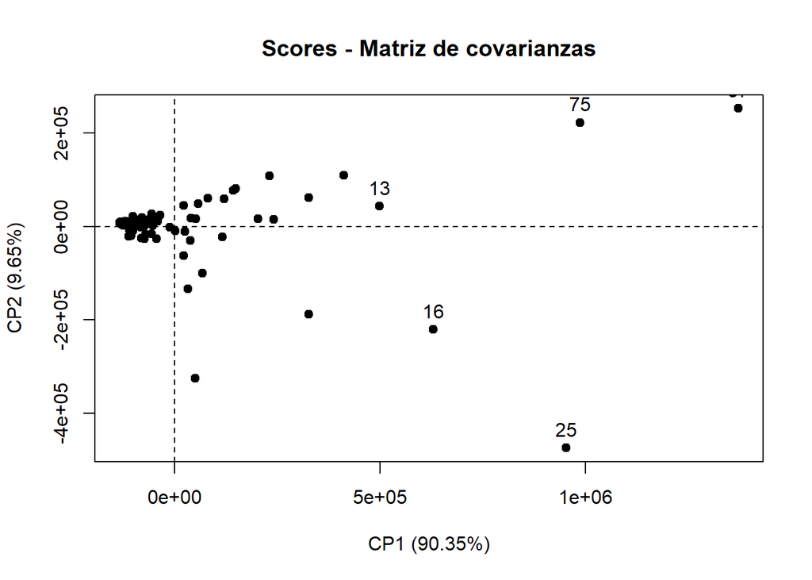

```r
dist_S <- sqrt(rowSums(scores_S[, 1:2]^2))
lejanos_S <- order(dist_S, decreasing = TRUE)[1:5]

plot(scores_S[,1], scores_S[,2],
     pch = 19,
     xlab = paste0("CP1 (", round(prop_S[1]*100, 2), "%)"),
     ylab = paste0("CP2 (", round(prop_S[2]*100, 2), "%)"),
     main = "Scores - Matriz de covarianzas")

abline(h = 0, v = 0, lty = 2)

text(scores_S[lejanos_S,1],
     scores_S[lejanos_S,2],
     labels = lejanos_S,
     pos = 3)
```

Países cercanos presentan perfiles similares, mientras que los puntos alejados presentan características diferentes al comportamiento general.

En este gráfico la separación está fuertemente influenciada por `PNB95` y `ProdElec`.

## 2. Scores con la matriz de correlaciones

Ahora las variables se estandarizan antes de calcular las puntuaciones.

```r
X_est <- scale(X)
scores_R <- X_est %*% vectores_R

head(scores_R[, 1:2])
```

```
##             CP1        CP2
## [1,] -0.7251030 -1.3839970
## [2,] -2.5683477 -0.6618184
## [3,]  0.3955072  3.7035812
## [4,] -1.1361307  1.3839854
## [5,]  0.4908447  0.5315512
## [6,]  3.4466131  0.6340814
```

### Gráfica de las dos primeras componentes

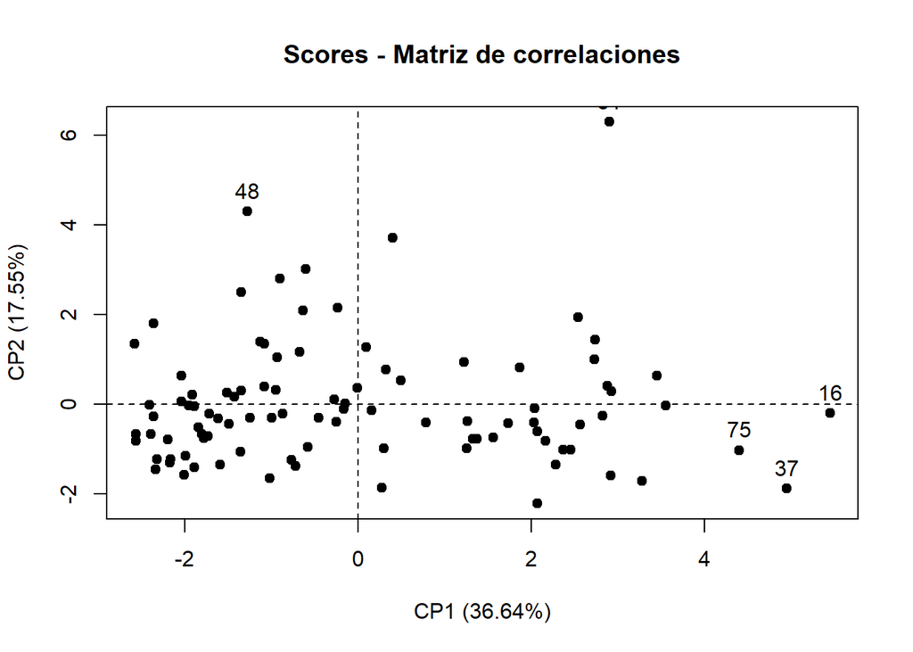

```r
dist_R <- sqrt(rowSums(scores_R[, 1:2]^2))
lejanos_R <- order(dist_R, decreasing = TRUE)[1:5]

plot(scores_R[,1], scores_R[,2],
     pch = 19,
     xlab = paste0("CP1 (", round(prop_R[1]*100, 2), "%)"),
     ylab = paste0("CP2 (", round(prop_R[2]*100, 2), "%)"),
     main = "Scores - Matriz de correlaciones")

abline(h = 0, v = 0, lty = 2)

text(scores_R[lejanos_R,1],
     scores_R[lejanos_R,2],
     labels = lejanos_R,
     pos = 3)
```

La distribución es más equilibrada porque todas las variables se encuentran en una escala comparable.

Las observaciones **31, 16, 37, 75 y 48** son las más alejadas en el plano CP1-CP2. Esto no significa automáticamente que sean errores, sino que tienen perfiles especialmente diferentes al resto.

```r
data.frame(
  Observacion = lejanos_R,
  CP1 = round(scores_R[lejanos_R,1], 3),
  CP2 = round(scores_R[lejanos_R,2], 3),
  Distancia = round(dist_R[lejanos_R], 3)
)
```

```
##   Observacion    CP1    CP2 Distancia
## 1          31  2.903  6.291     6.928
## 2          16  5.451 -0.197     5.454
## 3          37  4.951 -1.883     5.297
## 4          75  4.397 -1.025     4.515
## 5          48 -1.284  4.292     4.480
```

## 3. Uso de `princomp()`

La función `princomp()` permite obtener directamente componentes, cargas y puntuaciones.

```r
cpS <- princomp(X, cor = FALSE, scores = TRUE)
cpR <- princomp(X, cor = TRUE, scores = TRUE)

summary(cpS)
```

```
## Importance of components:
##                              Comp.1       Comp.2       Comp.3       Comp.4
## Standard deviation     2.469691e+05 8.070349e+04 2.141953e+03 5.545146e+02
## Proportion of Variance 9.034543e-01 9.647298e-02 6.795804e-05 4.554567e-06
## Cumulative Proportion  9.034543e-01 9.999273e-01 9.999953e-01 9.999998e-01
##                              Comp.5       Comp.6       Comp.7       Comp.8
## Standard deviation     1.096972e+02 2.254828e+01 1.894754e+01 6.704303e+00
## Proportion of Variance 1.782429e-07 7.530916e-09 5.317738e-09 6.657763e-10
## Cumulative Proportion  1.000000e+00 1.000000e+00 1.000000e+00 1.000000e+00
##                              Comp.9      Comp.10      Comp.11
## Standard deviation     2.395922e+00 1.192913e+00 6.869072e-01
## Proportion of Variance 8.502887e-11 2.107843e-11 6.989035e-12
## Cumulative Proportion  1.000000e+00 1.000000e+00 1.000000e+00
```

```r
summary(cpR)
```

```
## Importance of components:
##                           Comp.1    Comp.2    Comp.3     Comp.4    Comp.5
## Standard deviation     2.0074559 1.3892415 1.1706456 0.92979351 0.8911456
## Proportion of Variance 0.3663526 0.1754538 0.1245828 0.07859236 0.0721946
## Cumulative Proportion  0.3663526 0.5418065 0.6663893 0.74498164 0.8171762
##                            Comp.6     Comp.7     Comp.8     Comp.9    Comp.10
## Standard deviation     0.85393206 0.75584728 0.57166507 0.40996153 0.38252868
## Proportion of Variance 0.06629091 0.05193683 0.02970918 0.01527895 0.01330256
## Cumulative Proportion  0.88346715 0.93540398 0.96511315 0.98039210 0.99369467
##                            Comp.11
## Standard deviation     0.263360314
## Proportion of Variance 0.006305332
## Cumulative Proportion  1.000000000
```

Las cargas indican la relación de las variables con las componentes.

```r
round(cpR$loadings[, 1:2], 3)
```

```
##             Comp.1 Comp.2
## CrecPobl     0.314  0.348
## MortInf      0.392 -0.041
## PorcMujeres -0.117 -0.583
## PNB95       -0.295 -0.177
## ProdElec    -0.259 -0.174
## LinTelf     -0.446 -0.027
## ConsAgua    -0.092  0.321
## PropBosq    -0.006 -0.457
## PropDefor    0.244 -0.154
## ConsEner    -0.415  0.233
## EmisCO2     -0.375  0.292
```

Las puntuaciones indican la posición de cada observación.

```r
head(round(cpR$scores[, 1:2], 3))
```

```
##      Comp.1 Comp.2
## [1,]  0.729 -1.391
## [2,]  2.582 -0.665
## [3,] -0.398  3.723
## [4,]  1.142  1.391
## [5,] -0.493  0.534
## [6,] -3.465  0.637
```

`summary()` muestra la varianza explicada, `$loadings` contiene los coeficientes de las componentes y `$scores` contiene las puntuaciones de los países.

Los signos pueden aparecer invertidos respecto al cálculo con `eigen()`. Esto no cambia el resultado ni la interpretación del ACP.

## 4. Biplots

Para evitar la saturación del `biplot()` tradicional se utiliza `factoextra`. Los países se representan como puntos y las etiquetas se reservan para las variables.

```r
pca_S <- PCA(X, scale.unit = FALSE, ncp = ncol(X), graph = FALSE)
pca_R <- PCA(X, scale.unit = TRUE, ncp = ncol(X), graph = FALSE)
```

### Biplot de covarianzas

Debido al fuerte efecto de escala, se muestran las cinco variables con mayor contribución.

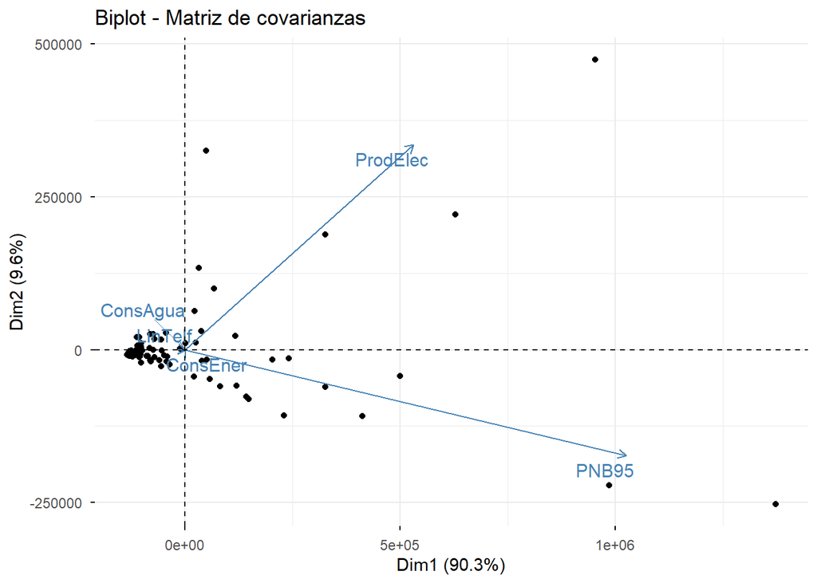

```r
fviz_pca_biplot(
  pca_S,
  geom.ind = "point",
  label = "var",
  select.var = list(contrib = 5),
  repel = TRUE,
  title = "Biplot - Matriz de covarianzas"
)
```

### Biplot de correlaciones

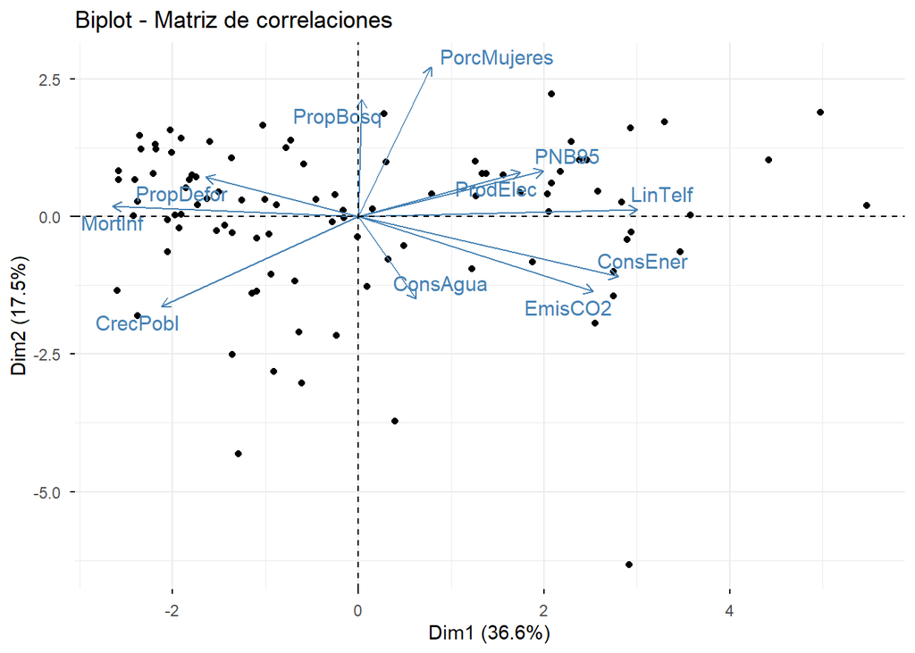

```r
fviz_pca_biplot(
  pca_R,
  geom.ind = "point",
  label = "var",
  repel = TRUE,
  title = "Biplot - Matriz de correlaciones"
)
```

En los biplots:

- Puntos cercanos representan países similares.
- Una observación situada en la dirección de una variable tiende a presentar valores altos en ella.
- Flechas en direcciones similares indican una relación positiva.
- Flechas opuestas indican una relación negativa.

El biplot de correlaciones resulta más informativo porque las variables tienen escalas comparables.

# PARTE III - Gráficos del Análisis de Componentes Principales

En esta parte se analizan los individuos, las variables, la varianza explicada y las contribuciones mediante `factoextra`.

## 1. Gráficos con la matriz de covarianzas

### 1.1 Individuos

Para evitar sobreponer 96 etiquetas se muestran únicamente los puntos.

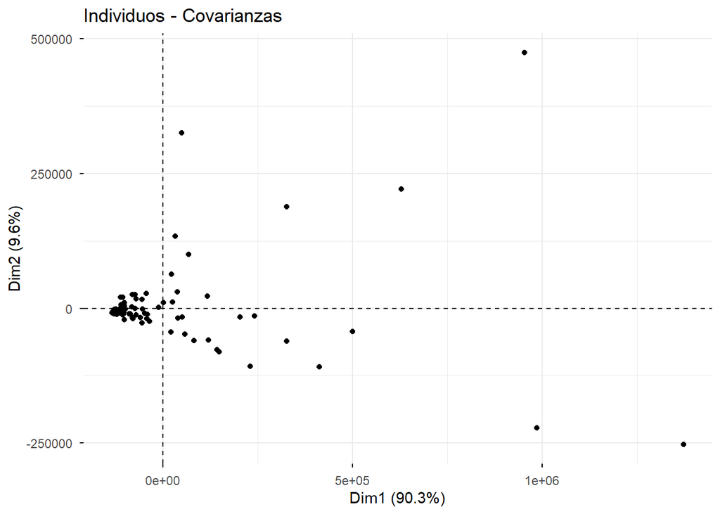

```r
fviz_pca_ind(
  pca_S,
  geom.ind = "point",
  title = "Individuos - Covarianzas"
)
```

Cada punto representa un país. Países cercanos tienen perfiles similares y los más alejados presentan características diferentes.

### 1.2 Variables

Como las diferencias de escala hacen que algunas variables dominen el gráfico, se muestran las cinco de mayor contribución.

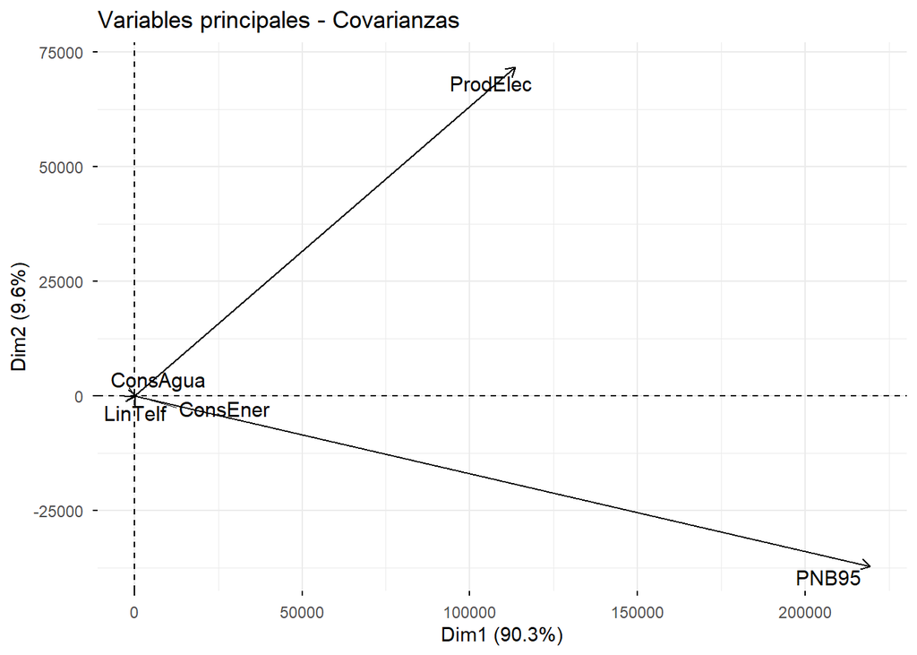

```r
fviz_pca_var(
  pca_S,
  select.var = list(contrib = 5),
  repel = TRUE,
  title = "Variables principales - Covarianzas"
)
```

`PNB95` y `ProdElec` dominan la representación. Esto confirma visualmente que el ACP con covarianzas está fuertemente influenciado por las variables de mayor escala.

### 1.3 Scree plot

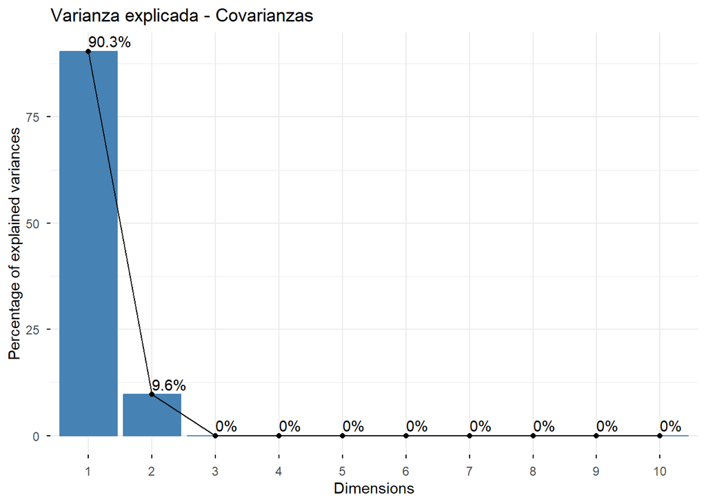

```r
fviz_screeplot(
  pca_S,
  addlabels = TRUE,
  title = "Varianza explicada - Covarianzas"
)
```

CP1 explica 90.35% y CP2 9.65%. La concentración casi total de la varianza en estas dos componentes se debe principalmente al efecto de las escalas originales.

### 1.4 Contribución de las variables

Se analiza la contribución conjunta al plano formado por CP1 y CP2.

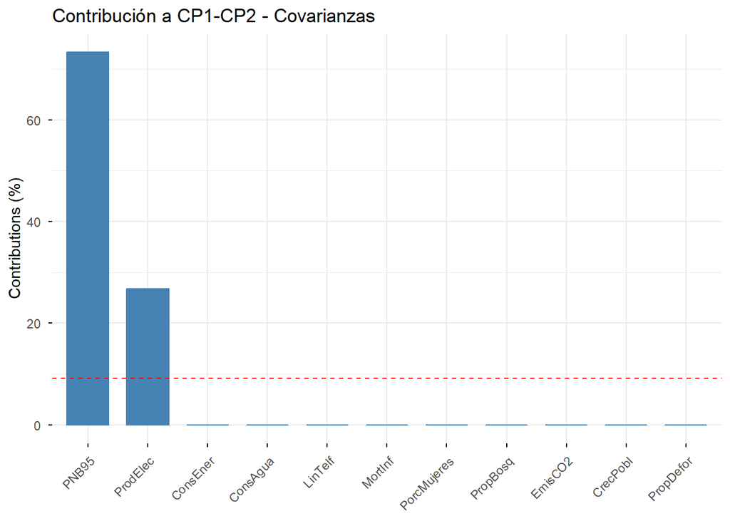

```r
fviz_contrib(
  pca_S,
  choice = "var",
  axes = 1:2,
  top = 11,
  title = "Contribución a CP1-CP2 - Covarianzas"
)
```

Las variables de gran escala concentran la mayor contribución, especialmente `PNB95` y `ProdElec`.

## 2. Gráficos con la matriz de correlaciones

### 2.1 Individuos

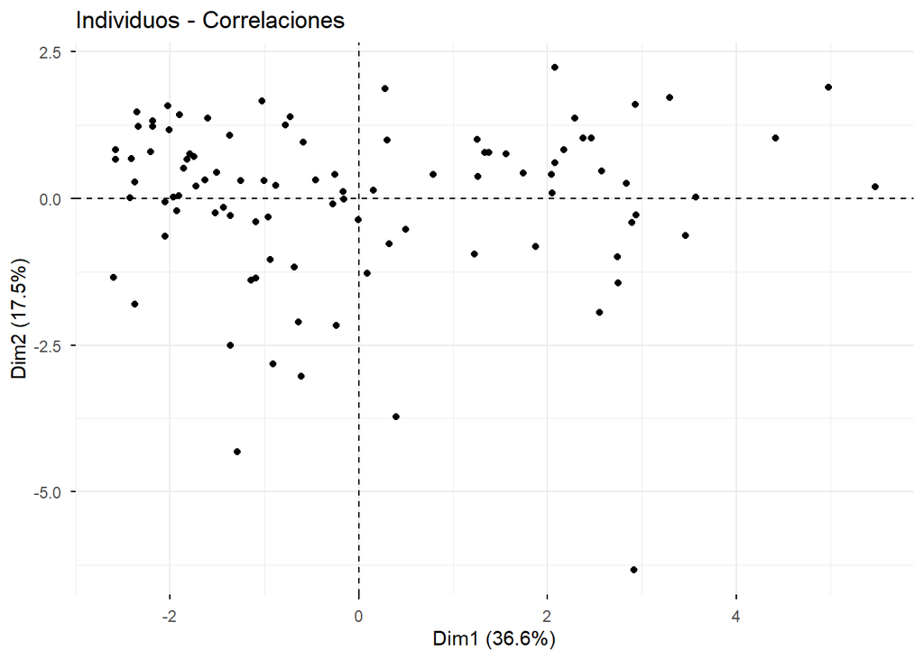

```r
fviz_pca_ind(
  pca_R,
  geom.ind = "point",
  title = "Individuos - Correlaciones"
)
```

La distribución de los países es más equilibrada porque ninguna variable domina únicamente por su escala.

Los puntos alejados representan países con perfiles económicos y sociales especialmente diferentes.

### 2.2 Variables

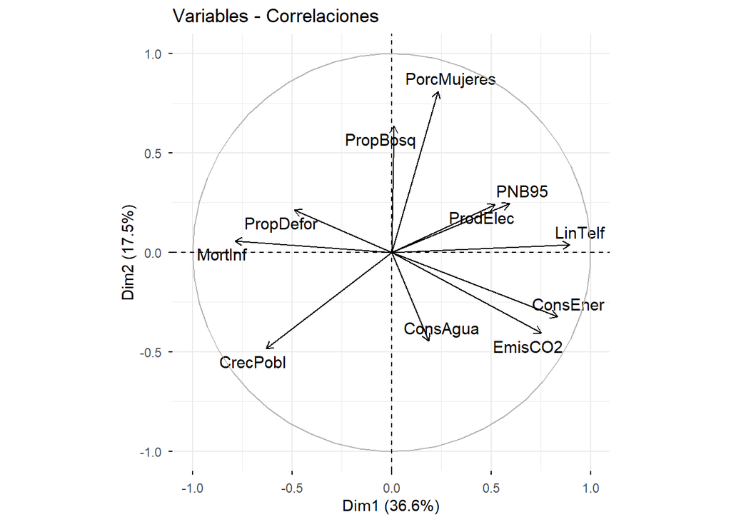

```r
fviz_pca_var(
  pca_R,
  repel = TRUE,
  title = "Variables - Correlaciones"
)
```

La dirección de las flechas permite estudiar las relaciones entre variables:

- Direcciones similares indican asociación positiva.
- Direcciones opuestas indican asociación negativa.
- Direcciones aproximadamente perpendiculares indican poca relación.

Además, la posición de cada flecha permite observar su relación con CP1 y CP2.

### 2.3 Scree plot

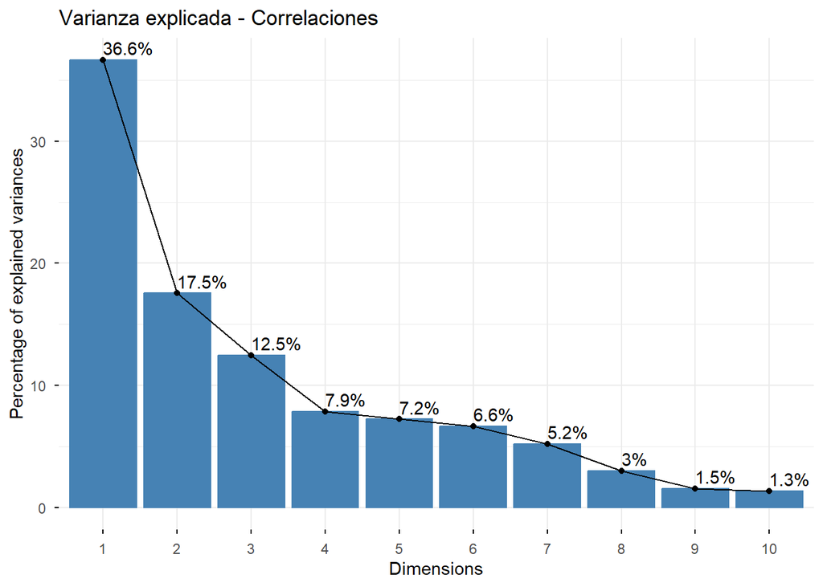

```r
fviz_screeplot(
  pca_R,
  addlabels = TRUE,
  title = "Varianza explicada - Correlaciones"
)
```

CP1 explica 36.64%, CP2 17.55% y CP3 12.46%.

Las primeras dos componentes acumulan 54.18% de la variabilidad y las primeras tres aproximadamente 66.64%.

### 2.4 Contribución de las variables

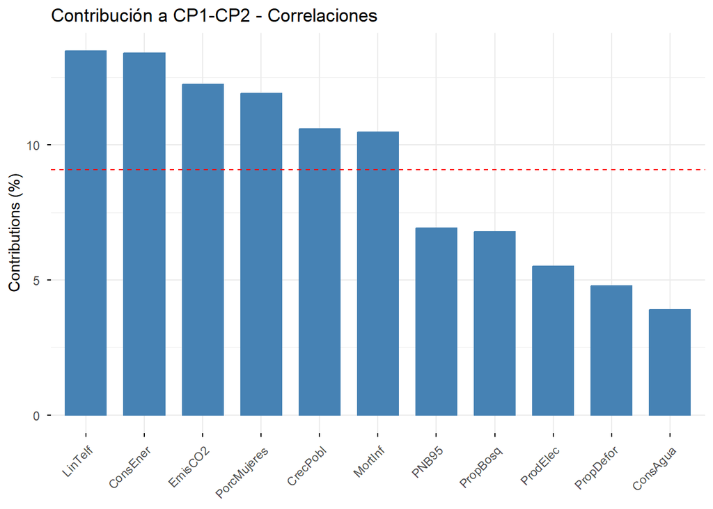

```r
fviz_contrib(
  pca_R,
  choice = "var",
  axes = 1:2,
  top = 11,
  title = "Contribución a CP1-CP2 - Correlaciones"
)
```

La contribución se encuentra distribuida entre distintas variables, lo que confirma que la estandarización evita que una o dos variables dominen todo el análisis.

## 3. Información adicional de `PCA()`

`PCA()` permite acceder directamente a los resultados utilizados para construir los gráficos.

```r
# Valores propios y varianza explicada
pca_R$eig
```

```
##         eigenvalue percentage of variance cumulative percentage of variance
## comp 1  4.02987902             36.6352638                          36.63526
## comp 2  1.92999195             17.5453813                          54.18065
## comp 3  1.37041115             12.4582832                          66.63893
## comp 4  0.86451597              7.8592361                          74.49816
## comp 5  0.79414057              7.2194597                          81.71762
## comp 6  0.72919997              6.6290906                          88.34671
## comp 7  0.57130511              5.1936828                          93.54040
## comp 8  0.32680096              2.9709178                          96.51132
## comp 9  0.16806846              1.5278951                          98.03921
## comp 10 0.14632819              1.3302563                          99.36947
## comp 11 0.06935866              0.6305332                         100.00000
```

```r
# Contribución de las variables
round(pca_R$var$contrib[, 1:2], 2)
```

```
##             Dim.1 Dim.2
## CrecPobl     9.87 12.14
## MortInf     15.40  0.17
## PorcMujeres  1.36 33.97
## PNB95        8.73  3.13
## ProdElec     6.71  3.01
## LinTelf     19.90  0.07
## ConsAgua     0.85 10.28
## PropBosq     0.00 20.92
## PropDefor    5.94  2.37
## ConsEner    17.22  5.42
## EmisCO2     14.03  8.51
```

```r
# Calidad de representación
round(pca_R$var$cos2[, 1:2], 2)
```

```
##             Dim.1 Dim.2
## CrecPobl     0.40  0.23
## MortInf      0.62  0.00
## PorcMujeres  0.05  0.66
## PNB95        0.35  0.06
## ProdElec     0.27  0.06
## LinTelf      0.80  0.00
## ConsAgua     0.03  0.20
## PropBosq     0.00  0.40
## PropDefor    0.24  0.05
## ConsEner     0.69  0.10
## EmisCO2      0.57  0.16
```

```r
# Scores de las observaciones
head(round(pca_R$ind$coord[, 1:2], 2))
```

```
##   Dim.1 Dim.2
## 1 -0.73  1.39
## 2 -2.58  0.67
## 3  0.40 -3.72
## 4 -1.14 -1.39
## 5  0.49 -0.53
## 6  3.46 -0.64
```

- `$eig` muestra los valores propios y la varianza explicada.
- `$var$contrib` indica cuánto aporta cada variable.
- `$var$cos2` muestra qué tan bien está representada cada variable.
- `$ind$coord` contiene las puntuaciones de los países.

Estas opciones permiten complementar la información observada en los gráficos.

# PARTE IV - Conclusiones

## 1. Comparación de los métodos

Los dos procedimientos permiten reducir la dimensión de los 11 indicadores, pero producen resultados distintos.

Con la matriz de covarianzas, CP1 y CP2 explican prácticamente toda la variabilidad. Sin embargo, el análisis está dominado por `PNB95` y `ProdElec` debido a sus grandes escalas.

Con la matriz de correlaciones, la varianza se distribuye entre más componentes porque todas las variables tienen una escala comparable.

Por lo tanto, para estos datos se recomienda utilizar la **matriz de correlaciones**.

## 2. Interpretación de CP1

Los coeficientes de mayor magnitud en CP1 corresponden principalmente a:

- `LinTelf`: 0.446
- `ConsEner`: 0.415
- `MortInf`: -0.392
- `EmisCO2`: 0.375
- `CrecPobl`: -0.314

También presentan coeficientes positivos `PNB95` y `ProdElec`.

Por ello, CP1 puede interpretarse como un **índice de desarrollo e industrialización**.

Valores altos de CP1 están asociados con mayor infraestructura telefónica, consumo de energía, producción económica y emisiones, junto con menor mortalidad infantil y crecimiento poblacional.

## 3. Interpretación de CP2

En CP2 las variables de mayor magnitud son:

- `PorcMujeres`: -0.583
- `PropBosq`: -0.457
- `CrecPobl`: 0.348
- `ConsAgua`: 0.321
- `EmisCO2`: 0.292

Esta componente puede interpretarse como una **dimensión demográfico-ambiental**, ya que contrapone principalmente crecimiento poblacional y consumo de recursos con participación femenina y superficie cubierta por bosques.

Su interpretación es menos directa que la de CP1.

## 4. Combinaciones lineales recomendadas

Debido a que se seleccionó la matriz de correlaciones, las componentes se construyen utilizando las variables estandarizadas.

$$\begin{aligned}
CP1 ={}& -0.3141Z_{CrecPobl}
-0.3924Z_{MortInf}
+0.1165Z_{PorcMujeres}\\
&+0.2954Z_{PNB95}
+0.2590Z_{ProdElec}
+0.4461Z_{LinTelf}\\
&+0.0924Z_{ConsAgua}
+0.0057Z_{PropBosq}
-0.2437Z_{PropDefor}\\
&+0.4150Z_{ConsEner}
+0.3745Z_{EmisCO2}
\end{aligned}$$

$$\begin{aligned}
CP2 ={}& 0.3484Z_{CrecPobl}
-0.0414Z_{MortInf}
-0.5828Z_{PorcMujeres}\\
&-0.1769Z_{PNB95}
-0.1736Z_{ProdElec}
-0.0272Z_{LinTelf}\\
&+0.3206Z_{ConsAgua}
-0.4574Z_{PropBosq}
-0.1541Z_{PropDefor}\\
&+0.2329Z_{ConsEner}
+0.2917Z_{EmisCO2}
\end{aligned}$$

donde:

$$Z_j=\frac{X_j-\bar
X_j}{s_j}$$

es la versión estandarizada de cada indicador.

## 5. Conclusión final

El ACP basado en la **matriz de correlaciones** resulta más adecuado para los indicadores económicos y sociales analizados, ya que evita que las diferencias de unidades y escalas dominen los resultados.

CP1 explica **36.64%** de la variabilidad y representa principalmente una dimensión de desarrollo e industrialización.

CP2 explica **17.55%** y representa principalmente una dimensión demográfico-ambiental.

En conjunto, las dos primeras componentes explican **54.18%** de la variabilidad. Son suficientes para realizar la representación bidimensional solicitada, aunque si se desea conservar más información pueden considerarse componentes adicionales.